# Multilevel Model Challenge With Experimental Data (with solutions)

Paul Bloom

7/12/2021

# An experimental dataset

Here, we’ll look at some pilot data from an experiment! In this experiment, the researchers manipulated the type of music that participants were exposed to – either a *familiar* condition where songs were by artists that participants had previously indicated they knew well, an *unfamiliar* condition where songs were by artists that participants had reported not knowing, and a *control* condition where the clips were not songs at all but instead weather and traffic clips. For today’s purposes, we’ll just focus on the *familiar* and *unfamiliar* conditions.

In particular, we’ll use multilevel models here because the data are *nested*! This is a *within-participants* study where each participant completed multiple listening trials in each condition. Because of this, a multilevel model will help us take into account that each person might respond differently to the manipulation (while still estimating the group-wide response)!

# Our question

Here we’ll ask the question: *did clips in the familiar condition evoke more positive emotions than clips in the unfamiliar condition*

Participants rated how each clip made them feel immediately after listening on a likert-type scale from *1 (extremely negative)* to *7 (extremely positive)*, in the `musicValence` column

```r
library(tidyverse)
library(rstanarm)
library(tidybayes)
```

# Data cleaning (you don’t have to change anything here)

```r
df = read_csv('https://raw.githubusercontent.com/pab2163/amfm_public/master/pilot_data/pilot_responses.csv') %>%
  dplyr::filter(condition != 'C', is.na(Skipped)) %>%
  dplyr::select(Year, Title, Artist, Genre, condition, musicValence, familiarityRating, participantID) %>%
  dplyr::mutate(condition = dplyr::recode(condition, 'F' = 'Familiar', 'U' = 'Unfamiliar'))


head(df, 3)
```

# 1. Model the effect of condition on evoked emotions (`musicValence`)

Make a multilevel model using `rstanarm::stan_glm()` with random slopes and intercepts for each participant

```r
vm = rstanarm::stan_glmer(data = df, musicValence ~ condition + (condition | participantID))
```

# 2. Interpret the model. How would you describe the effect of `condition` on `musicValence`?

```r
m_summary = summary(vm, probs = c(.025, .975))
m_summary[1:5,]
```

```
##                                                      mean        mcse        sd
## (Intercept)                                    5.72406510 0.011839586 0.4197725
## conditionUnfamiliar                           -0.76073525 0.009579719 0.3617231
## b[(Intercept) participantID:pilot007]         -0.05638515 0.012626759 0.4721663
## b[conditionUnfamiliar participantID:pilot007]  0.62669272 0.011705870 0.4751995
## b[(Intercept) participantID:pilot008]          0.50418256 0.012054689 0.4638101
##                                                     2.5%       97.5% n_eff
## (Intercept)                                    4.8224795  6.57335992  1257
## conditionUnfamiliar                           -1.4766210 -0.02750033  1426
## b[(Intercept) participantID:pilot007]         -1.0230932  0.86263653  1398
## b[conditionUnfamiliar participantID:pilot007] -0.1524269  1.67313737  1648
## b[(Intercept) participantID:pilot008]         -0.3833722  1.50394494  1480
##                                                    Rhat
## (Intercept)                                   1.0005199
## conditionUnfamiliar                           1.0013919
## b[(Intercept) participantID:pilot007]         0.9995995
## b[conditionUnfamiliar participantID:pilot007] 1.0014827
## b[(Intercept) participantID:pilot008]         1.0016159
```

Looks like on average, `musicValence` is lower by about -0.7607353, 95% PI [-1.476621, -0.0275003] or the unfamiliar condition as compared to the familiar condition. So, within 95% confidence, our model thinks that the unfamiliar condition causes `musicValence` to be lower relative to the familiar condition.

# 3. Use `spread_draws()` to get the full posterior distribution for the `conditionUnfamilar` term, and plot the posterior distribution for this effect

Hint: `stat_halfeye()` is a good way to go here

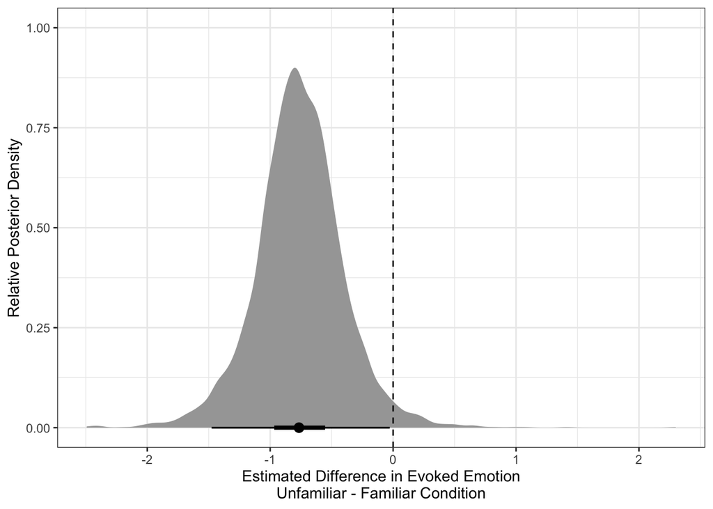

```r
condition_posterior = vm %>% spread_draws(conditionUnfamiliar)

ggplot(condition_posterior, aes(x = conditionUnfamiliar)) +
  stat_halfeye(.width = c(0.5, 0.95)) +
  labs(x = 'Estimated Difference in Evoked Emotion\nUnfamiliar - Familiar Condition', y = 'Relative Posterior Density') +
  theme_bw() +
  geom_vline(xintercept = 0, lty = 2)
```

We can see that the 95% posterior interval comes pretty close to 0 but doesn’t overlap here. What does it mean if it *comes close to 0?* What if we plotted the 97% posterior interval instead and used that to make a decision?

# 4. Plot the model predictions for `musicValence` for each condition

First plot the predictions for `musicValence` in each condition for the group average, but then also overlay predictions for each participant

Bonus: connect each participant’s mean (or median) prediction for each condition to make ‘slopes’. Which participant has the steepest slope?

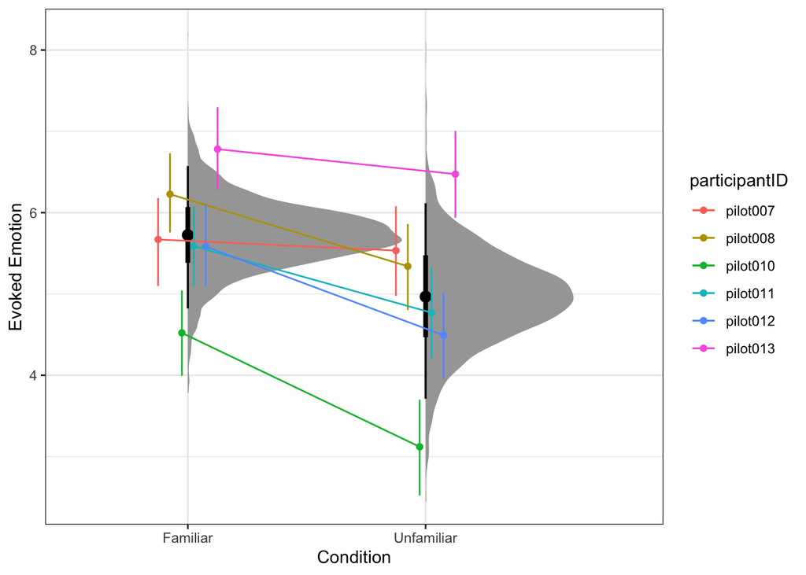

```r
pred_frame = data.frame(condition = c('Unfamiliar', 'Familiar'))
pred_frame_participants = expand.grid(condition = c('Unfamiliar', 'Familiar'), participantID = unique(df$participantID), stringsAsFactors = FALSE)

# use re_formula = NA so that the random effects aren't considered
vm_predictions = tidybayes::add_fitted_draws(newdata = pred_frame, model = vm, re_formula = NA)


# now consider the random effects
vm_predictions_participant = tidybayes::add_fitted_draws(model = vm, newdata = pred_frame_participants) %>%
  median_qi()
ggplot(vm_predictions, aes(x = condition, y = .value)) +
  stat_halfeye() +
  geom_point(data = vm_predictions_participant,
                     aes(x = condition, y = .value, color = participantID),
                     position = position_dodge(.3)) +
   geom_errorbar(data = vm_predictions_participant,
                     aes(x = condition, y = .value, ymin = .lower, ymax = .upper, color = participantID),
                     position = position_dodge(.3),
                     width = 0) +
  geom_line(data = vm_predictions_participant,
                     aes(x = condition, y = .value, color = participantID, group = participantID),
                     position = position_dodge(.3)) +
  labs(y = 'Evoked Emotion', x = 'Condition') +
  theme_bw()
```

# 5. Compare the model predictions to the raw data by making a panel plot

Make 1 panel for each participant with `condition` on the x-axis and `musicValence` on the y-axis. Plot both the model predictions and the raw data (or participant-level means and standard errors for `musicValence`).

Is the model making good predictions for each participant? Are there any participants where the model is predicting particularly well or poorly?

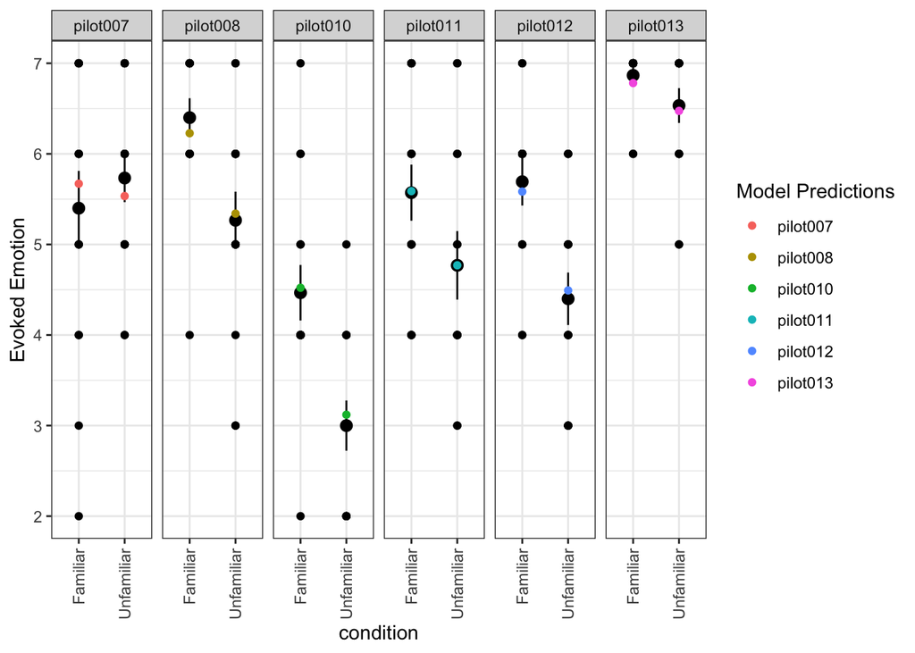

```r
ggplot(data = df, aes(x = condition, y = musicValence)) +
  geom_point() +
  stat_summary(fun.data = mean_se) +
  geom_point(data = vm_predictions_participant,
                     aes(x = condition, y = .value, color = participantID),
                     position = position_dodge(.3)) +
  facet_grid(~participantID) +
  labs(color = 'Model Predictions') +
  theme_bw() +
  labs(y = 'Evoked Emotion') +
  theme(axis.text.x = element_text(angle = 90, vjust = 0.5, hjust=1))
```

> - The model predictions are not *exactly* the same as the raw data for all participants becuase the model is *partial pooling* – because the model considers all participants’ random slopes and intercepts to each come from normal distributions, the model *pools* people to look more like one another.
> - For example, because 5/6 participants show more positive evoked emotion in the familiar condition, the model is pulling the estimates for `pilot007` to show an effect in this direction (red points) when the raw data for this participant actually go in the opposite direction (more positive emotion in the unfamiliar condition). However, the model’s effect for `pilot007` isn’t fully pooled – the estimated effect for this participant is weaker for the other participants, meaning the model is taking into account both the participant-level data and group-level data simultaneously.

# 6. Run a posterior predictive check using `pp_check()`

Does the distribution of the model’s predictions for `musicValence` seem to match the actual distribution of `musicValence`?

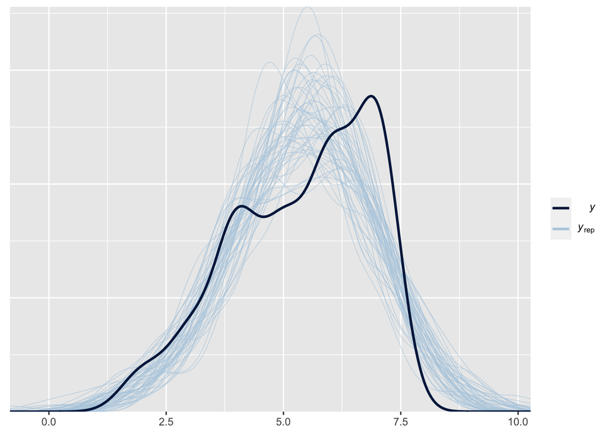

```r
pp_check(vm)
```

Not really, the model is predicting a normal distribution when the distribution of the actual `musicValence` is more ‘lumpy’

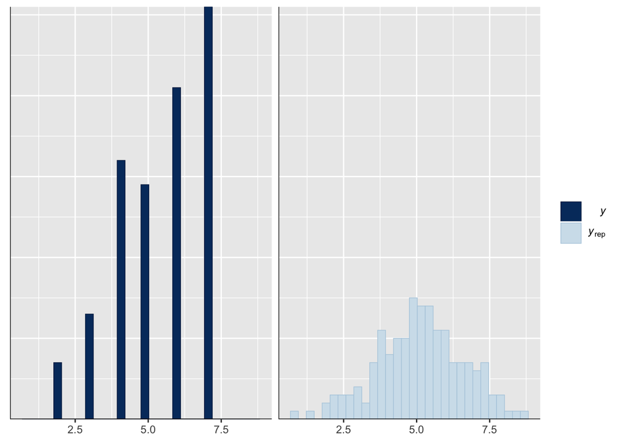

```r
pp_check(vm, plotfun = 'ppc_hist', nreps = 1)
```

> - Now we can see the model isn’t doing so well matching the distribution because `musicValaence` responses are *ordinal* on a Likert scale from 1-7. In fact, the only responses in the real data were in `[2,3,4,5,6,7]`.
> - Since the model is a linear regression, it is assuming the outcome variable is normally distributed. This can’t *really* be true since likert-type data are bounded (they have a minimum and maximum) and no responses can be given between integers. Next time, we can talk about some models that might make better assumptions given likert-type data!